# GF-0604 Procesamiento de datos geográficos Laboratorio 04: R - Datos raster 1

Steven Guillén Rivera

2020-06-16

## Descripción general

En este laboratorio, elaborará un mapa web con el paquete [Leaflet](https://cran.r-project.org/web/packages/leaflet/) del lenguaje de programación [R](https://www.r-project.org/), para visualizar datos ambientales y de biodiversidad. El resultado final será un documento en la sintaxis [R Markdown](https://rmarkdown.rstudio.com/), publicado en [GitHub Pages](https://pages.github.com/).

## Fecha de entrega y entregables

La fecha límite de entrega de este laboratorio es el **jueves 18 de junio de 2020**. **NO SE ACEPTARÁN ENTREGAS DESPUÉS DE ESA FECHA**. Debe enviarle al profesor por correo electrónico la dirección del sitio en GitHub Pages resultante.

La tarea puede realizarse en grupos de un máximo de tres estudiantes.

## Trabajo previo

Se recomienda leer el material preparado por el profesor y consultar los recursos listados en:

- [Lección 10: el lenguaje de programación R - Datos raster](https://geoprocesamiento-2020i.github.io/leccion-10-r-datos-raster/).

## Tareas a realizar

Elabore un mapa web que contenga:

1. (10%) Tres capas base tipo `Tile`.
2. (20%) Dos capas raster: altitud y promedio de precipitación, provenientes de la base de datos [WorldClim](https://www.worldclim.org/) y recortadas para los límites de Costa Rica y en resolución de 30x30 segundos.
3. (20%) Dos capas vectoriales correspondientes a los registros de presencia de las especies de aves [Ara ambiguus](https://github.com/geoprocesamiento-2020i/datos/blob/master/biodiversidad/registros-presencia/cr/cr-ara-ambiguus.geojson) (lapa verde) y [Pharomachrus mocinno](https://github.com/geoprocesamiento-2020i/datos/blob/master/biodiversidad/registros-presencia/cr/cr_pharomachrus_mocinno.geojson) (quetzal).
4. (20%) Un control de capas que permita activar y desactivar todas las capas.
5. (20%) Leyendas para las dos capas raster. Elija con cuidado las paletas de colores de ambas capas.
6. (10%) Un control de mapa de referencia (*MiniMap*).

Los mapas deben ser implementados con el paquete `Leaflet`.

```r
# Paquete para manejo de datos vectoriales
library(sf)
# Paquete de Tidyverse para manipulación de datos
library(dplyr)
# Paquete para mapas en la Web
library(leaflet)
```

```r
# Instalación del paquete raster
install.packages("raster")
# Instalación del paquete raster
install.packages("rgdal")
```

```r
# Carga del paquete raster
library(raster)
# Carga del paquete rgdal
library(rgdal)
```

```r
# Directorio de trabajo
setwd("c:/users/CEACOT-B/")
# Consulta del directorio de trabajo
getwd()
```

```
## [1] "c:/users/CEACOT-B"
```

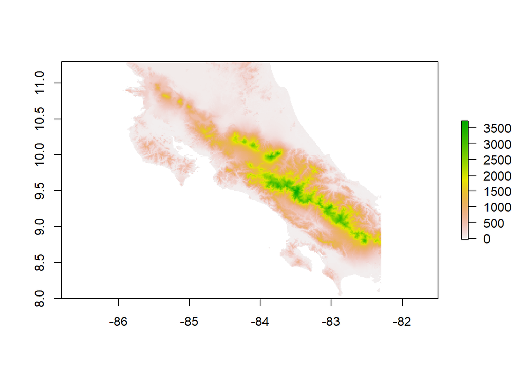

```r
# Datos de altitud
altitude <- getData("worldclim", var="alt", res=.5, lon=-84, lat=10)
# Datos de altitud recortados para los límites aproximados de Costa Rica
cr_altitude <- crop(altitude, extent(-86, -82.3, 8, 11.3))
plot(cr_altitude)
```

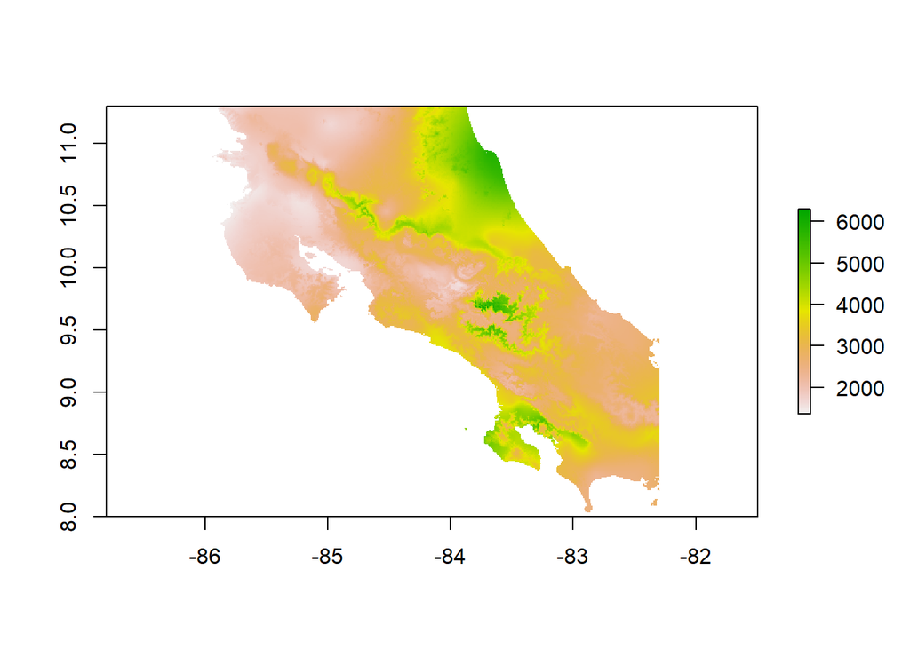

```r
# Datos de precipitación anual
 precipitation <- getData("worldclim", var="bio", res=.5, lon=-84, lat=10)
 # Datos de precipitación anual recortados para los límites aproximados de Costa Rica
 cr_precipitation <- crop(precipitation$bio12_23, extent(-86, -82.3, 8, 11.3))
 plot(cr_precipitation)
```

```r
# Registros de presencia de Ara ambiguus (lapa verde) en Costa Rica
cr_ara_ambiguus <-
  st_read(
    "https://raw.githubusercontent.com/geoprocesamiento-2020i/datos/master/biodiversidad/registros-presencia/cr/cr-ara-ambiguus.geojson"
  )
```

```r
# Registros de presencia de Pharomachrus mocinno (quetzal) en Costa Rica
cr_pharomachrus_mocinno <-
  st_read(
    "https://raw.githubusercontent.com/geoprocesamiento-2020i/datos/master/biodiversidad/registros-presencia/cr/cr_pharomachrus_mocinno.geojson"
  )
```

#### Confección de mapas

```r
 pal <- colorNumeric(
   c("#507e4e","#e5ff00","#ff0000"),
   values(cr_altitude),
   na.color = "transparent"
 )

 pall <- colorBin("Blues",values(cr_precipitation) , na.color = "transparent")

m <- leaflet() %>%
  addProviderTiles(providers$Esri.WorldImagery, group = "Imágenes de ESRI") %>%
  addProviderTiles(providers$Stamen.TonerLite, group = "Stamen Toner Lite") %>%
  addProviderTiles(providers$OpenStreetMap.Mapnik, group = "OpenStreetMap") %>%
  addCircleMarkers(data = cr_ara_ambiguus,
                   stroke = F,
                   radius = 4,
                   fillColor = 'green',
                   fillOpacity = 1,
                   group = "Ara ambiguus",
                   popup = paste(cr_ara_ambiguus$locality,
                                 cr_ara_ambiguus$year,
                                 sep = '<br/>'
                           )
  ) %>%

   addCircleMarkers(data = cr_pharomachrus_mocinno,
                   stroke = F,
                   radius = 3,
                   fillColor = 'red',
                   fillOpacity = 1,
                   group = "Pharomachrus mocinno",
                   popup = paste(cr_pharomachrus_mocinno$locality,
                                 cr_pharomachrus_mocinno$year,
                                 sep = '<br/>'
                           )
  ) %>%

  addRasterImage(cr_altitude,
                 colors = pal,
                 opacity = 0.8,
                 group = "Altitud"
  ) %>%
    addRasterImage(cr_precipitation,
                 colors = pall,
                 opacity = 0.8,
                 group = "Precipitación anual"
  ) %>%
  addLayersControl(
    baseGroups = c("OpenStreetMap", "Stamen Toner Lite", "Imágenes de ESRI"),
    overlayGroups = c("Altitud", "Ara ambiguus","Pharomachrus mocinno","Precipitación anual"),
    options = layersControlOptions(collapsed = FALSE)
  ) %>%
  addLegend(pal = pal,
            values = values(cr_altitude),
            title = "Altitud"
  ) %>%

  addLegend(pal = pall,
            values = values(cr_precipitation),
            position = "topleft",
            title = "Precipitación anual"
  ) %>%
  addMiniMap(
    toggleDisplay = TRUE,
    position = "bottomleft",
    tiles = providers$Stamen.TonerLite
  )
```

```r
# Despliegue del mapa
m
```

[interactive chart not shown]